# Report: Estimating the Impact of Groundwater Allocation Policies on Irrigation Behavior

## 2.2 Find farmers who used more than 9 inches-acre in LR.

- Do they have any common characteristics?
- Type of farmers (Corporation, Organization, individual farmer)
- If a single landowner has multiple farmlands, he should have allocated his total pumping limitation to his all farmlands every year through **Pooling Arrangement**.

Who used more than 9 inches in which year?

| owner_name | num_field | num_overuse | overuse_Years |
| --- | --- | --- | --- |
| Allan Marilyn Karen Elaine_Kuhlman Meyer Zounes Brunke | 1 | 1 | 2012 |
| Anthony_Fisher | 2 | 1 | 2012 |
| Arnold_Quadhamer | 5 | 1 | 2012 |
| Bernice M_Grass | 1 | 1 | 2012 |
| Bradley J_Quadhamer | 2 | 1 | 2012 |
| Brent B & Rogene L_Hinrichs | 1 | 1 | 2012 |
| Burdette & Gwendolyn_Jameson | 1 | 1 | 2012 |
| C Jarvis & Maxine K_Miller | 2 | 1 | 2012 |
| C_Schroeder Farms Inc | 1 | 1 | 2012 |
| Carl J_Woollen | 1 | 1 | 2012 |
| Carl W & Arlan L_Leising | 1 | 1 | 2012 |
| Chad_Lindau | 2 | 1 | 2012 |
| Clark E_Andrews | 2 | 1 | 2012 |
| Claudia J_Anderson Revocable Trust | 1 | 1 | 2012 |
| Clayton H Grace & David_Schubert | 1 | 1 | 2012 |
| Craig B & Renee A_Grams | 5 | 1 | 2012 |
| Dale I_Schwartz | 1 | 1 | 2012 |
| Dale_Frerichs | 1 | 1 | 2012 |
| Darlene_Fischer | 1 | 1 | 2012 |
| David C_Nickel | 1 | 1 | 2012 |
| David_Black | 3 | 1 | 2012 |
| Deleard L_Pettijohn | 1 | 1 | 2009 |
| Dewey_Knuth | 1 | 1 | 2012 |
| Donald & Sue_Johnson | 1 | 1 | 2012 |
| Dorene_Hinrichs | 1 | 1 | 2012 |
| Doug_Reed | 1 | 1 | 2012 |
| Doyle & Pauline_Morse | 1 | 1 | 2012 |
| Eugene & Jeanne_Ortgiesen | 1 | 1 | 2012 |
| F Wayne & Judith_Huxoll | 1 | 1 | 2012 |
| Floyd_Fisher | 1 | 1 | 2012 |

[output cut: 255 more lines]

```r
over20_LR <-
  reg_data %>%
  .[usage > 20 & nrdname=="Lower Republican",] %>%
  .[,owner_name := paste0(firstname, "_", lastname)] %>%
  .[,.(usage, year, owner_name, longdd, latdd)] %>%
  ownr_distinct_fld_LR[., on=c("owner_name", "longdd", "latdd")]

# length(over20_LR[, owner_name] %>% unique()) #285

tbl_over20_LR <-
  over20_LR %>%
  .[, .(
    num_field = mean(num_fields),
    num_overuse = .N,
    overuse_Years = sapply(
      .SD, function(x) unique(x)%>% sort()%>% paste0(., collapse=", ")
      )
    ), .SDcols = "year", by = owner_name]

tbl_over20_LR %>%
  .[order(num_overuse, owner_name)] %>%
  gt() %>%
  cols_align(align = "center", columns = c("num_field", "num_overuse")) %>%
  cols_align(align = "right", columns = "overuse_Years") %>%
  tab_style(
    style = list(cell_fill(color = "lightcyan")),
    locations = cells_body(columns = c("num_overuse","overuse_Years"))
  )%>%
  tab_header(title = md("Who used more than 20 inches in which year?"))
```

Who used more than 20 inches in which year?

| owner_name | num_field | num_overuse | overuse_Years |
| --- | --- | --- | --- |
| Cecil & Donna J_Guthrie | 1 | 1 | 2012 |
| Clyde & Jerry_Lueking | 17 | 1 | 2012 |
| Doyle & Pauline_Morse | 1 | 1 | 2012 |
| Ervin E_Warner | 3 | 1 | 2012 |
| Gary W_Jensen | 1 | 1 | 2012 |
| Gregory A & Barbara K_Choquette | 2 | 1 | 2012 |
| James L_Reiss Rev Trust | 3 | 1 | 2012 |
| Jerry_Rutt | 2 | 1 | 2012 |
| Karen_Hawley | 1 | 1 | 2012 |
| Kenneth E_Schoen Trust | 14 | 1 | 2012 |
| Lavern C_Stuehm Revocable Trust | 1 | 1 | 2012 |
| Marc M & Janet_Rasmussen | 3 | 1 | 2012 |
| Margaret D_Ackerman | 1 | 1 | 2012 |
| Max O & Marjean R_Schultz Revocable Trusts | 5 | 1 | 2012 |
| Maxine_Hemelstrand | 8 | 1 | 2012 |
| Mona_Bunger | 10 | 1 | 2012 |
| Randy_Sandman | 1 | 1 | 2012 |
| Ronald & Susan_Woollen | 1 | 1 | 2012 |
| Stephen & Melanie_Johnson | 6 | 1 | 2012 |
| William & Sharon_Nielsen Farms Inc | 3 | 1 | 2012 |
| _EP Farm LLC | 2 | 1 | 2012 |
| _Enstrom Farms LLC | 7 | 1 | 2012 |
| Bob_Dorn | 2 | 2 | 2008, 2009 |
| David R & Susan_Maaske | 8 | 2 | 2012 |
| Douglas K & Cheryl_Schutz | 8 | 2 | 2012 |
| George W_McNiel | 4 | 2 | 2012 |
| Ronald R & Carol S_Ivey Trusts | 4 | 2 | 2012 |
| Shari_Mues | 2 | 2 | 2012 |
| Thomas & Debbie_Kruse | 3 | 2 | 2009, 2010 |
| _Sanderson Farms Inc | 2 | 2 | 2011, 2012 |
| _Reiss Farms Inc | 10 | 3 | 2009, 2011, 2012 |
| Charles & Margaret_Hermes | 4 | 4 | 2008, 2009, 2010, 2011 |
| _Hoffman Inc | 3 | 4 | 2008, 2009, 2010, 2011 |
| Nicholas & Christopher_Holste | 2 | 7 | 2008, 2009, 2010, 2011 |

# 3 Conclusion

## 3.1 Other Concerns

- source: “Sustainability Steps – Previous and Planned Actions in the Republican Basin to Preserve Water” (https://www.urnrd.org/sites/default/files/files/20/sustainabilitysteps2021.pdf)
- The
  - “With participation in federal and state **conservation programs** designed to reduce water use, more than 13,000 irrigated acres have been permanently or temporarily retired. This respresents over 4% of the toral irrigated acres in the LRNRD”
    - The federal Conservation Reserve Program (CRP)?
    - The rule-book (7-) says that any landowner participating in such conversation programs is not eligible to receive an allocation. But once his contract of any conservation program is over, a landowner will become eligible for an allocation. In this case, he can receive allocation for the remaining years of Allocation Period.
  - “The District has also promoted a **cost-share program to encourage the use of water-saving soil-moisture probes**. The probes have been installed on approximately 60,000 acres.”

# 4 The patter of missing data

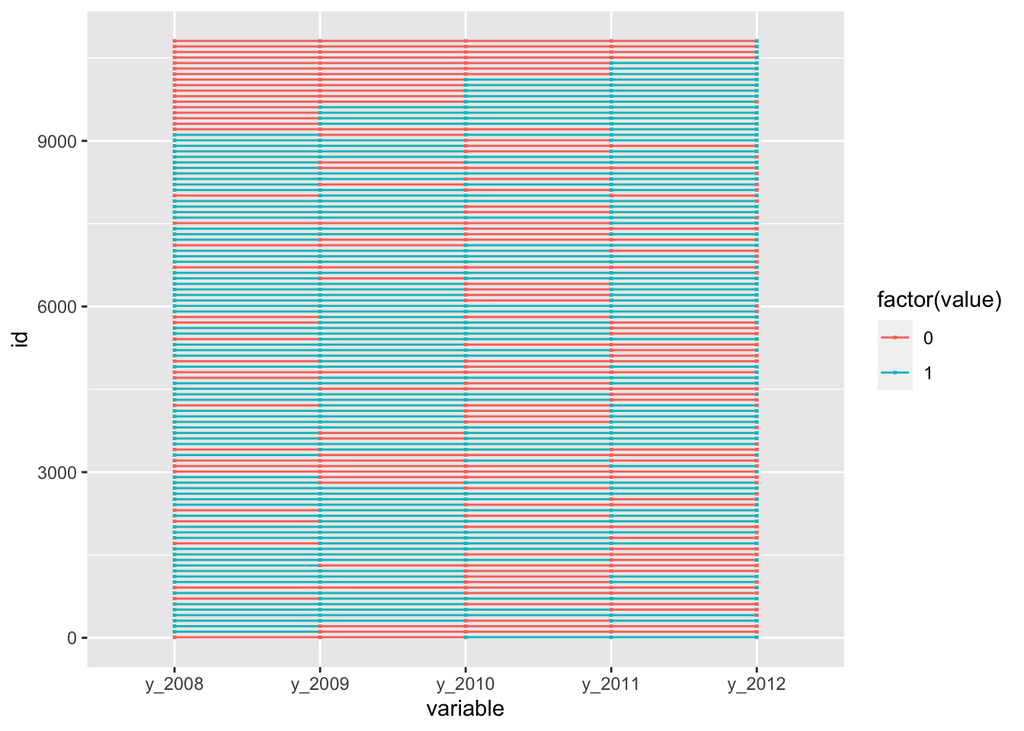

```r
survive_trt_group <-
  # reg_data_all %>%
  reg_data %>%
  .[nrdname=="Lower Republican", ] %>%
  .[,.(wellid, year)] %>%
  .[,year := paste0("y_", year)] %>%
  .[,data_index := 1] %>%
  dcast(wellid ~ year, value.var = "data_index")


survive_trt_group[is.na(survive_trt_group)] <- 0

survive_trt_group2 <-
  copy(survive_trt_group) %>%
  .[, total := rowSums(.SD), by = wellid]


lon_survive_trt_group <-
   survive_trt_group2[total<=4, !"total"] %>%
   .[,id := seq(from=10, by=100, length.out = nrow(.))] %>%
   melt(id.vars = c("wellid", "id"), measure.vars = names(.)[-c(1,7)])

ggplot(lon_survive_trt_group, aes(x = variable, y = id, group = id, col = factor(value)))+
  geom_line(size = 0.5) +
  geom_point(shape = 15, size = 0.5)
```

```r
lon_survive_trt_group3 <-
   copy(survive_trt_group2) %>%
   .[total<=4, !"total"] %>%
   .[,survie_index := case_when(
    y_2008==1 & y_2009==1 & y_2010==1 & y_2011==1 & y_2012==0 ~ "f4",
    y_2008==1 & y_2009==1 & y_2010==1 & y_2011==0 & y_2012==0 ~ "f3",
    y_2008==1 & y_2009==1 & y_2010==1 & y_2011==0 & y_2012==0 ~ "f3",
    y_2008==1 & y_2009==1 & y_2010==0 & y_2011==0 & y_2012==0 ~ "f2",
    y_2008==1 & y_2009==0 & y_2010==0 & y_2011==0 & y_2012==0 ~ "f1",
    TRUE ~ "f0"
    )]

lon_survive_trt_group3 %>%
  .[, .N, by = survie_index]
```

[output not shown]

```r
well_f0 <- lon_survive_trt_group3[survie_index=="f0", wellid]
well_f1 <- lon_survive_trt_group3[survie_index=="f1", wellid]
well_f2 <- lon_survive_trt_group3[survie_index=="f2", wellid]
well_f3 <- lon_survive_trt_group3[survie_index=="f3", wellid]
well_f4 <- lon_survive_trt_group3[survie_index=="f4", wellid]

dt_f1 <-
  copy(reg_data) %>%
  .[, idn :=case_when(
      wellid %in% well_f1 ~ "f1",
      wellid %in% well_f2 ~ "f2",
      wellid %in% well_f3 ~ "f3",
      wellid %in% well_f4 ~ "f4",
      wellid %in% well_f0 ~ "f0"
      )]

# dt_f1[idn != "f0"] %>%
#   ggplot() +
#   geom_line(aes(x=year, y=usage, group = wellid, color=factor(wellid)))+
#   geom_line(aes(x=year, y=usage, group = wellid, color=factor(wellid)))+
#   facet_wrap( ~ idn, ncol=2)
```

# 5 References

- “LOWER REPBULICAN NATURAL RESOURCES DISTRICT AMENDED AND RESTATED GROUND WATER MANAGEMENT RULES AND REGULATIONS” - CHAPTER 7 (https://www.lrnrd.org/docman/docs/478-groundwater-rules-and-regulations-clean-3-9-17/file)
- “Sustainability Steps – Previous and Planned Actions in the Republican Basin to Preserve Water” (https://www.urnrd.org/sites/default/files/files/20/sustainabilitysteps2021.pdf)